# bank_marketin_ex2

```r
# Packages required
library(rsample)
library(caret)
library(tidyverse)
```

```r
library(inspectdf)
library(ISLR)
library(dplyr)
library(ggplot2)
library(recipes)
library(psych)
# Model interpretability packages
library(vip)       # variable importance
library(ROCR)      # ROC curve
```

```r
#http://archive.ics.uci.edu/ml/datasets/Bank+Marketing

#read the data set
bank <- read.csv2("data/bank-additional-full.csv", dec = ".")
```

convert all characters to factors

```r
bank[sapply(bank, is.character)] <- lapply(bank[sapply(bank, is.character)],
                                       as.factor)
```

drop duration and nr.employed columns

```r
bank <- select(bank, c (-duration, - nr.employed))
```

take smaller train set to check if the training method works well

```r
set.seed(123) # for reproducibility
split <- initial_split(bank, strata = "y", prop = 0.025)
train <- training(split)
```

```r
cv <- trainControl(
  method = "repeatedcv",
  number = 10,
  repeats = 5
  )

# 4. create a hyperparameter grid search
hyper_grid <- expand.grid(k = seq(2, 8, by = 2))
```

Create and a apply a blueprint of feature engineering processes that you think will help your model improve.

```r
blueprint <- recipe(y ~ ., data = train) %>%
  step_nzv(all_nominal()) %>%
  step_center(all_numeric(), -all_outcomes()) %>%
  step_scale(all_numeric(), -all_outcomes()) %>%
   step_dummy(all_nominal(), -all_outcomes(), one_hot = TRUE)
  #step_integer(all_nominal()) %>%
```

#Portfolio Builder Exercise 2

##1 Depending on the type of response variable, apply a linear or logistic regression model.

First, apply the model to your data without pre-applying feature engineering processes.

** multicliniarity check ho to solve it ???

```r
set.seed(123)
(preBp_model <- train(
  y ~ .,
  data = train,
  method = "glm",
  family = "binomial",
  trControl = trainControl(method = "cv", number = 10)
))
```

```
## Generalized Linear Model
##
## 1030 samples
##   18 predictor
##    2 classes: 'no', 'yes'
##
## No pre-processing
## Resampling: Cross-Validated (10 fold)
## Summary of sample sizes: 927, 926, 927, 928, 928, 927, ...
## Resampling results:
##
##   Accuracy   Kappa
##   0.8952073  0.2996285
```

Now reapply the model to your data that has feature engineered.(blueprint/ preprocess?)

```r
set.seed(123)
(Bp_model <- train(
  blueprint,
  data = train,
  method = "glm",
  family = "binomial",
  trControl = trainControl(method = "cv", number = 10)
))
```

```
## Generalized Linear Model
##
## 1030 samples
##   18 predictor
##    2 classes: 'no', 'yes'
##
## Recipe steps: nzv, center, scale, dummy
## Resampling: Cross-Validated (10 fold)
## Summary of sample sizes: 927, 926, 927, 928, 928, 927, ...
## Resampling results:
##
##   Accuracy   Kappa
##   0.8952073  0.2996285
```

Did your model performance improve?

##2 Apply a principal component regression model. Perform a grid search over several components. Identify and explain the performance of the optimal model.

principal component regression model is not applicable for classification tasks!

##3 Apply a partial least squares regression model. Perform a grid search over several components.

*****this should not work just to make sure try and test it

```r
cv <- trainControl(
  method = "repeatedcv",
  number = 10,
  repeats = 5
  )

hyper_grid_p <- expand.grid(ncomp = seq(2, 10, by = 2))


# PLS
set.seed(123)
cv_pls <- train(
  blueprint,
  data = train,
  trControl = cv,
  method = "pls", #<<
  tuneGrid = hyper_grid_p
  )
# model with lowest RMSE
cv_pls$bestTune
```

```
##   ncomp
## 1     2
```

```r
cv_pls$results %>%
  filter(ncomp == as.numeric(cv_pls$bestTune))
```

```
##   ncomp  Accuracy     Kappa AccuracySD   KappaSD
## 1     2 0.9019583 0.2810833 0.01390087 0.1205494
```

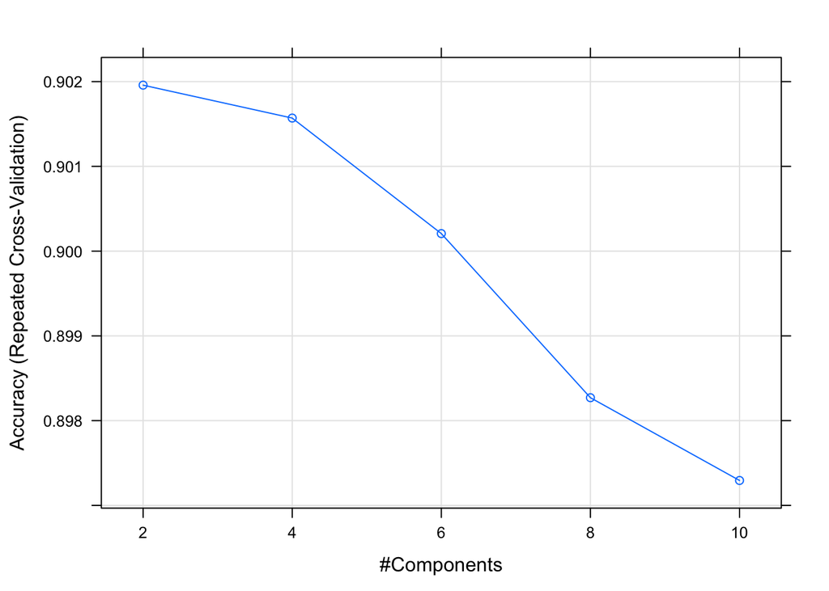

```r
# plot cross-validated RMSE
plot(cv_pls)
```

Identify and explain the performance of the optimal model.

##4

Apply a regularized regression model. Perform a grid search across alpha parameter values ranging between 0–1.

regularized regression model can not be applied in classification tasks!

What is the optimal alpha and lambda values? What is the MSE and RMSE for this optimal model? How does it compare to your previous models?